# telluric

## Interactive vector and raster geospatial data manipulation in Python

#### Guy Doulberg - 2018-06-05 @ PyCon-IL

https://github.com/satellogic/telluric-talks

[figure not shown]

# [**Satellogic**](https://www.satellogic.com/)

- We are building a constellation of satellites that orbits earth.
- We are building an infrastructure to collect and store data (mostly images) from this constellation.
- We are producing insights out of this data and other sources of data.
- We are hiring

[figure not shown]

# Guy

- I am part of the team which is responsilbe for collecting stroing and accesing the Raster and Vector Data in *Satellogic*.
- Software engineers with experience in big data projects.

# 1. Quick intro to geospatial data

> **Geospatial data**, geographic data, georeferenced data, or just geodata "are defined in the ISO/TC 211 series of standards as data and information having an implicit or explicit association with a location relative to the Earth"

> -- https://en.wikipedia.org/wiki/Geographic_data_and_information

> A **geographic information system (GIS)** is a system designed to capture, store, manipulate, analyze, manage, and present spatial or geographic data.

> -- https://en.wikipedia.org/wiki/Geographic_information_system

## Two forms: vector and raster

- **Vector data**: Discrete, mathematical entities
- **Raster data**: Rectangular grids

[figure not shown]

Image by Víctor Olaya "Sistemas de Información Geográfica", CC-BY

## Vector data

- **Entities**: Points, Lines and Polygons
- **Common formats**: ESRI Shapefiles, GeoJSON, TopoJSON, ...

[figure not shown]

Image by M. W. Toews https://en.wikipedia.org/wiki/File:Simple_vector_map.svg, CC-BY

## Raster data

- **Common formats**: GeoTIFF, JPEG2000, SRTM3, ...

[figure not shown]

## Projections

TL;DR: A mess.

- The Earth is approximately a sphere, which is not a [developable surface](https://en.wikipedia.org/wiki/Developable_surface) (i.e. *it cannot be flattened onto a plane without distortion*)
- Therefore, we need *projections* that attempt to represent the Earth on a plane, with various tradeoffs and limitations

[figure not shown]

# 2. Why yet another Existing software

The landscape is complicated and somewhat difficult to navigate at times:

[figure not shown]

Summary of key libraries:

| Python |  | C/C++ |
| --- | --- | --- |
| pyproj | ⇒ | PROJ.4 |
| Fiona | ⇒ | OGR |
| Shapely | ⇒ | GEOS |
| rasterio | ⇒ | GDAL |

From the Fiona documentation:

```
with fiona.drivers():
    with fiona.open('tests/data/coutwildrnp.shp') as source:
        meta = source.meta
        meta['schema']['geometry'] = 'Point'
        with fiona.open('test_write.shp', 'w', **meta) as sink:
            for f in source.filter(bbox=(-107.0, 37.0, -105.0, 39.0)):
               f['geometry'] = {'type': 'Point',
                    'coordinates': f['geometry']['coordinates'][0][0]}
                sink.write(f)
```

# 3. telluric library

*telluric is an open source (MIT) Python library to manage vector and raster geospatial data in an interactive and easy way.*

- Projection-aware geometric operations
- Simple I/O for raster and vector data
- Interactive visualization
- 🕮 Documentation http://telluric.readthedocs.io/
- 🔧 Source https://github.com/satellogic/telluric

Importing for interactive use is short:

```python
import telluric as tl
from telluric.constants import WGS84_CRS, WEB_MERCATOR_CRS
```

Basic geometry definition using `GeoVector`: in the simplest case, the bounds and the projection (CRS)

```python
gv1 = tl.GeoVector.from_bounds(
    xmin=34.6, ymin=32, xmax=35.0, ymax=32.3, crs=WGS84_CRS
)
print(gv1)
```

```
GeoVector(shape=POLYGON ((34.6 32, 34.6 32.3, 35 32.3, 35 32, 34.6 32)), crs=CRS({'init': 'epsg:4326'}))
```

```python
gv1
```

[interactive chart not shown]

Using Shapely geometries is also allowed:

```python
from shapely.geometry import Polygon

gv2 = tl.GeoVector(
    Polygon([(34.6, 32), (34.6, 32.3), (35,32.3), (35, 32), ( 34.6, 32)]),
    WGS84_CRS
)
gv2
```

[interactive chart not shown]

Access several properties:

```python
gv1.centroid
```

[interactive chart not shown]

```python
gv1.area  # Real area in square meters
```

```
1259014132.9260154
```

```python
gv1.within(gv2)
```

```
True
```

```python
print(gv1.difference(gv2))
```

```
GeoVector(shape=GEOMETRYCOLLECTION EMPTY, crs=CRS({'init': 'epsg:4326'}))
```

- Features: `GeoVector` + attributes
- `FeatureCollection`s: a sequence of features

```python
gf1 = tl.GeoFeature(
    gv1,
    {'name': 'One feature'}
)
gf2 = tl.GeoFeature(
    gv2,
    {'name': 'Another feature'}
)
print(gf1)
print(gf2)
```

```
GeoFeature(Polygon, {'name': 'One feature'})
GeoFeature(Polygon, {'name': 'Another feature'})
```

```python
fc = tl.FeatureCollection([gf1, gf2])
fc
```

[interactive chart not shown]

Raster data:

```python
# This will only save the URL in memory
rs = tl.GeoRaster2.open(
    "https://github.com/mapbox/rasterio/raw/master/tests/data/rgb_deflate.tif"
)

# These calls will fecth some GeoTIFF metadata
# without reading the whole image
print(rs.crs)
print(rs.footprint())
print(rs.band_names)
```

```
CRS({'init': 'epsg:32618'})
GeoVector(shape=POLYGON ((101984.9999999127 2826915, 339314.9999997905 2826915, 339314.9999998778 2611485, 101985.0000002096 2611485, 101984.9999999127 2826915)), crs=CRS({'init': 'epsg:32618'}))
[0, 1, 2]
```

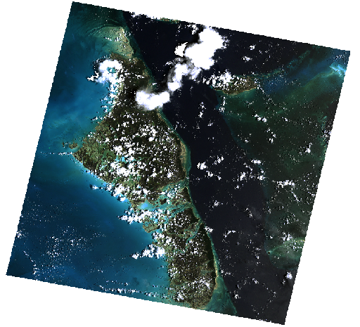

```python
rs
```

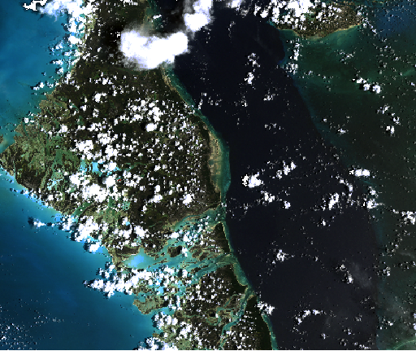

```python
rs.crop(rs.footprint().buffer(-50000))
```

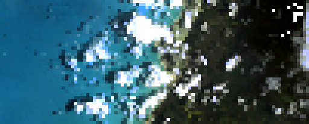

```python
rs[200:300, 200:240]
```

```python
# Rasterizing Vectors
# Geting OpenStreetMap data of Tel Aviv
from shapely.geometry import shape
import json

with open("telaviv.geojson") as data:
    features = json.load(data)["features"]
    fc = tl.FeatureCollection([tl.GeoFeature(tl.GeoVector(shape(feature["geometry"])),feature["properties"]) for feature in features])
fc
```

[interactive chart not shown]

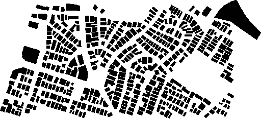

```python
streets_raster = fc.rasterize(dest_resolution=1)
streets_raster
```

# Distributed Computation

- We can use the *rasterazation* and *crop* methods to distriubte the workload
- Imagine a 1m resultion of entire Israel is about 20 GB
- Imagine that you have hundereds of these rasters
- We suggest the following to distriute the computation on the rasters

```python
from telluric.vectors import generate_tile_coordinates

list_of_regions = list(generate_tile_coordinates(rs.footprint(), num_tiles=(10,10)))

# This line is to visualize and not required
tl.FeatureCollection(tl.GeoFeature(tile, {}) for tile in list_of_regions)
```

[interactive chart not shown]

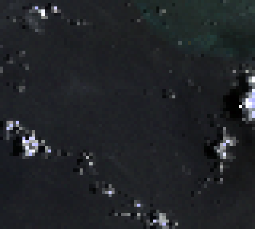

```python
chunk0 = rs.crop(list_of_regions[17])
chunk0
```

```python
def worker(raster_filename, roi):
     raster = tl.GeoRaster2.open(raster_filename) #Lazy loading of the raster
     chunk0 = raster.crop(roi)
     return chunk0.image.max()

import dask.multiprocessing, dask
RASTER_URL="https://github.com/mapbox/rasterio/raw/master/tests/data/rgb_deflate.tif"
items = [dask.delayed(worker)(RASTER_URL, roi) for roi in list_of_regions]

maxs = dask.compute(*items, get=dask.multiprocessing.get)
```

```python
from numpy.ma.core import MaskedConstant

max([val for val in maxs if not isinstance(val,MaskedConstant)])
```

```
255
```

# 4. Internal uses at Satellogic

- Visualize the captures from our satellites
- Estimate the coverage and do area computations
- Large scale geospatial raster and vector data ingestion and manipulation

# 5. Future work

- 🐛 List of issues https://github.com/satellogic/telluric/issues
- Better visualization (good performance, unified approach)
- Simpler constructors for objects
- Better handling of corner cases (specially the antimeridian)
- More advanced geometrical operations (such as geodesic buffering)
- ...Surprises

# Questions?

- 🕮 http://telluric.readthedocs.io/
- 🔧 https://github.com/satellogic/telluric, https://github.com/satellogic/telluric

[figure not shown]